# Predictive diagnosis of breast cancer tumour class through analysis of cytological characteristics of breast cancer cells.

Jorge Fernández Alfonso ISSU2028: Data Science & Big Data Analytics - 2018

August 08, 2018

## Introduction

The aim of this report is to present an analysis and exploration of the [Wisconsin Breast Cancer Database](http://math.furman.edu/~dcs/courses/math47/R/library/mlbench/html/BreastCancer.html), which is a dataset that contains a set of variables in a number of patients known to have breast cancer. The final goal of this analysis is to compare the performance of classification models and decision trees to predict if a certain tumor is benign or malignant given the available predictors in the dataset.

### Section 1

#### Section 1.1: Setup

The first step in our analysis is to load the libraries that are going to be used throughout the process. Please note that if any of this code returns an error message, it might be necessary to install the packages before using them, which can be easily done by running this in the R console:

> install.packages(“name_of_package”)

Then the proceed to load the data and run a series of basic commands to get a feel for the basic characteristics of the dataset. We also rename the variables for better code readability.

```r
  #load packages
  library(class)
  library(dplyr)
    library(corrplot)
  library(caret)
  library(ggplot2)
  library(mice)
  library(tidyr)
  library(doParallel)
  library(e1071)
  library(gridExtra)
  library(gbm)
  library(MASS)
  library(tree)
  library(randomForest)

  #load data and run basic exploratory commands
  breastCancer <- read.csv("breast-cancer-wisconsin.data.csv")
  attach(breastCancer)
  summary(breastCancer)
```

```
##    id.number        Clump.Thickness  Uniformity.of.Cell.Size
##  Min.   :   61634   Min.   : 1.000   Min.   : 1.000
##  1st Qu.:  870688   1st Qu.: 2.000   1st Qu.: 1.000
##  Median : 1171710   Median : 4.000   Median : 1.000
##  Mean   : 1071704   Mean   : 4.418   Mean   : 3.134
##  3rd Qu.: 1238298   3rd Qu.: 6.000   3rd Qu.: 5.000
##  Max.   :13454352   Max.   :10.000   Max.   :10.000
##
##  Uniformity.of.Cell.Shape Marginal.Adhesion Single.Epithelial.Cell.Size
##  Min.   : 1.000           Min.   : 1.000    Min.   : 1.000
##  1st Qu.: 1.000           1st Qu.: 1.000    1st Qu.: 2.000
##  Median : 1.000           Median : 1.000    Median : 2.000
##  Mean   : 3.207           Mean   : 2.807    Mean   : 3.216
##  3rd Qu.: 5.000           3rd Qu.: 4.000    3rd Qu.: 4.000
##  Max.   :10.000           Max.   :10.000    Max.   :10.000
##
##   Bare.Nuclei  Bland.Chromatin  Normal.Nucleoli     Mitoses
##  1      :402   Min.   : 1.000   Min.   : 1.000   Min.   : 1.000
##  10     :132   1st Qu.: 2.000   1st Qu.: 1.000   1st Qu.: 1.000
##  2      : 30   Median : 3.000   Median : 1.000   Median : 1.000
##  5      : 30   Mean   : 3.438   Mean   : 2.867   Mean   : 1.589
##  3      : 28   3rd Qu.: 5.000   3rd Qu.: 4.000   3rd Qu.: 1.000
##  8      : 21   Max.   :10.000   Max.   :10.000   Max.   :10.000
##  (Other): 56
##      Class
##  Min.   :2.00
##  1st Qu.:2.00
##  Median :2.00
##  Mean   :2.69
##  3rd Qu.:4.00
##  Max.   :4.00
##
```

```r
  names(breastCancer)
```

```
##  [1] "id.number"                   "Clump.Thickness"
##  [3] "Uniformity.of.Cell.Size"     "Uniformity.of.Cell.Shape"
##  [5] "Marginal.Adhesion"           "Single.Epithelial.Cell.Size"
##  [7] "Bare.Nuclei"                 "Bland.Chromatin"
##  [9] "Normal.Nucleoli"             "Mitoses"
## [11] "Class"
```

```r
  dim(breastCancer)
```

```
## [1] 699  11
```

```r
  #rename variables
  breastCancer <- dplyr::rename(breastCancer,
                 ID=id.number,
         thickness=Clump.Thickness,
         size_uniformity=Uniformity.of.Cell.Size,
         shape_uniformity=Uniformity.of.Cell.Shape,
         adhesion=Marginal.Adhesion,
         size_epithelial=Single.Epithelial.Cell.Size,
         bare_nuclei=Bare.Nuclei,
         bland_chromatin=Bland.Chromatin,
         normal_nucleoli=Normal.Nucleoli,
         mitoses=Mitoses)

  #split data into training and test (57 : 43)
    train <- sample(1:nrow(breastCancer),400)
    breastCancer.training <- breastCancer[train,]
    breastCancer.test <- breastCancer[-train,]
```

#### Section 1.2: Initial Exploratory Plots

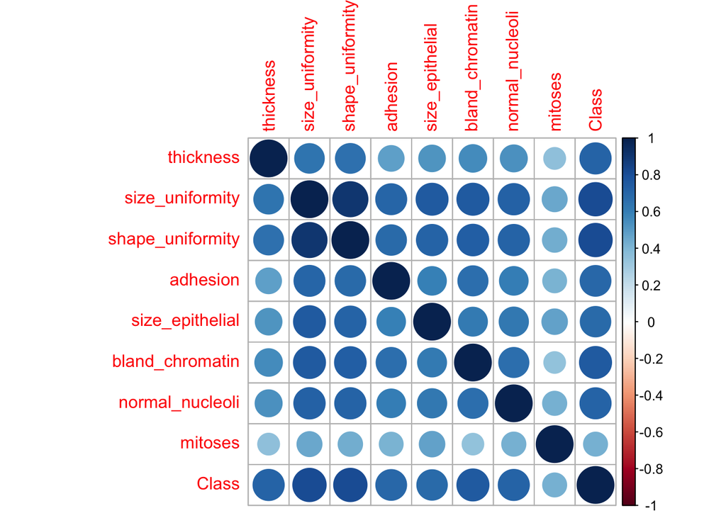

```r
  #Computing and plotting the correlation matrix to see how variables stack up against each other
    M <- cor(breastCancer[,c(2:6,8:11)])
    corrplot(M, method = "circle")
```

Upon looking at the plot of the predictors’ correlation matrix one might think that *mitoses* plays little to no role in helping predict wether the tumor will turn out to be benign or not.

Of course, this assumpion may be incorrect because although the predictor doesn’t seem to be relevant on its own, its interaction with other predictors may very well be so. For the time, being, we will not discard mitosis as a potential predictor until we see the results of section 1.3.

After seeing how the different predictors relate to each other and to the outcome variable, we are interested in visualizing how the distribution of the predictors differs between a benign and a malignant tumor.

In order to visualize this we build a series of histograms where we stack up the values of each parameter in a benign tumor (Class = 2) against the values in a malignant tumor (Class = 4).

```r
  breastCancer[,2:10] <- apply(breastCancer[, 2:10], 2, function(x) as.numeric(as.character(x)))
```

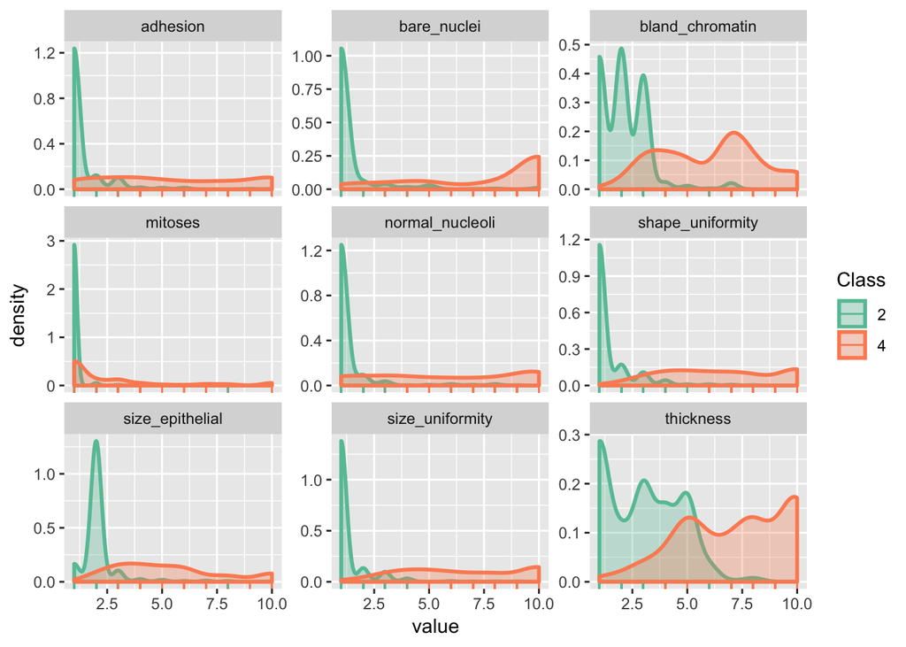

```r
  dataset_impute <- mice(breastCancer[, 2:10],  print = FALSE)
  breastCancer <- cbind(breastCancer[, 11, drop = FALSE], mice::complete(dataset_impute, 1))

  breastCancer$Class <- as.factor(breastCancer$Class)

  breastCancer_gather <- breastCancer %>%
    tidyr::gather(measure, value, thickness:mitoses)

  ggplot(data = breastCancer_gather, aes(x = value, fill = Class, color = Class)) +
    geom_density(alpha = 0.3, size = 1) +
    geom_rug() +
    scale_fill_brewer(palette = "Set2") +
    scale_color_brewer(palette = "Set2") +
    facet_wrap( ~ measure, scales = "free_y", ncol = 3)
```

This plot allows us to clearly realize that in a benign tumor most of the parameters tend to have a lower value and a much lower range than in a malignant tumor. Therefore, it makes sense to think that if a tumor presents abnormally large values in several parameters at the same time, it probably is a malignant tumor.

#### Section 1.3: Trying to find the best predictor (or set of predictors)

In this section we face the problem of trying to infer which combination of predictors will produce an optimal outcome and more accurate prediction. In order to solve this, we will write a function that computes the importance of each of the parameters:

```r
  registerDoParallel()
  #performs crossvalidation 10 times through 10 folds
  control <- trainControl(method = "repeatedcv", number = 10, repeats = 10)

  feature_imp <- function(model, title, subtitle="") {

  #estimates variable importance
  importance <- varImp(model, scale = TRUE)

  #prepare dataframes for plotting
  importance_df_1 <- importance$importance
  importance_df_1$group <- rownames(importance_df_1)

  importance_df_2 <- importance_df_1
  importance_df_2$Overall <- 0

  importance_df <- rbind(importance_df_1, importance_df_2)

  #build the plot
  plot <- ggplot() +
    geom_point(data = importance_df_1, aes(x = Overall, y = group, color = group), size = 2) +
    geom_path(data = importance_df, aes(x = Overall, y = group, color = group, group = group), size = 1) +
    theme(legend.position = "none") +
    labs(
      x = "Importance",
      y = "",
      title = title,
      subtitle = subtitle
    )

  #return the plot we just built as a result
  return(plot)
  }
```

Now we will predict the importance of each of the predictors taking two different approaches: random forest and boosted trees.

Random forest is a supervised learning algorithm that works both for classification and regression tasks. It works by building a set of trees which in turn merges so as to get a more precise prediction.

Boosting is a technique that can also be applied to classification and regression problems, and is particularly useful in the context of decision trees.

In sectinon 4 we will introduce bagged trees. Bagging is a procedure that involves creating multiple copies of the original training data set using the bootstrap, fitting a separate decision tree to each copy, and then combining all of the trees in order to create a single predictive model.

Boosting works in a similar way, but each tree now is grown using information from previously grown trees.

Having provided an explanation for those concepts, we now proceed to use the function in combination with these techniques:

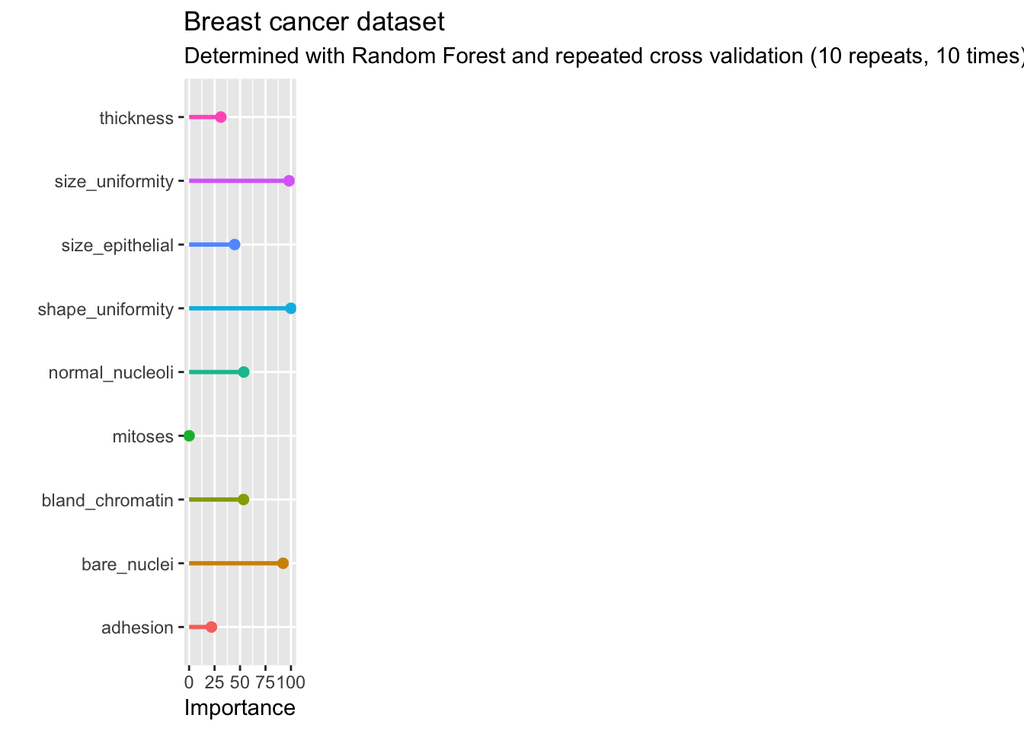

```r
  #we turn Class into a factor variable so as to run the importance function
  breastCancer$Class = as.factor(breastCancer$Class)

  #we change nuclei to a numeric variable
  breastCancer$bare_nuclei = as.numeric(breastCancer$bare_nuclei)

  set.seed(27)

  #we now use random forest (mehtod = "rf") to train the data
  imp_md <- train(Class ~ ., data = breastCancer, method = "rf", preProcess = c("scale", "center"), trControl = control)

  #and we plot it
  p1 <- feature_imp(imp_md, title = "Breast cancer dataset", subtitle = "Determined with Random Forest and repeated cross validation (10 repeats, 10 times) ")
  grid.arrange(p1, ncol = 3, widths = c(0.3, 0.35, 0.35))
```

It can be seen that the random forest method returns *size_uniformity*, *shape_uniformity* and *bare_nuclei* as the three strongest predictors. Let’s compare this outcome to the one we will get when we use the function and the boosting trees approach:

```r
  set.seed(27)
  #we now use bosting (mehtod = "gbm") to train the data
  imp_md <- train(Class ~ ., data = breastCancer, method = "gbm", preProcess = c("scale", "center"), trControl =control)
```

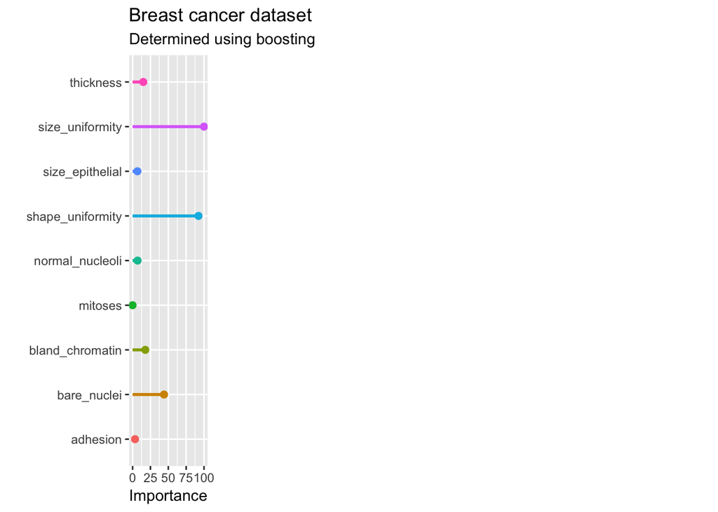

```r
  #and plot it
  p1 <- feature_imp(imp_md, title = "Breast cancer dataset", subtitle = "Determined using boosting")
  grid.arrange(p1, ncol = 3, widths = c(0.3, 0.35, 0.35))
```

This time, the strongest predictors are *size_uniformity*, *shape_uniformity* and *bare_nuclei*, which are exactly the same as in the previous instance. Therefore, we can be very sure that, in fact, these will turn out to be very strong indicators of wether a tumor is benign or not.

### Section 2. Decision Trees I: Boosted Trees

In this section (and the upcoming ones), we will classify the tumors into benign or malignant using a range of statistical learning techniques and compute the misclassification rate for each of them. Our ultimate goal is to decide on an optimal classification model weighting the advantages and drawbacks of each of the methods.

#### Section 2.1: Creation of the Model

```r
  library("gbm")
  set.seed(100)

  #turn the values in the factor variable Class (2 and 4) to 0 and 1 to represent benign and malignant tumors respectively
  breastCancer$Class_binary <- ifelse(breastCancer$Class == 2,0,
                            ifelse(breastCancer$Class == 4, 1, NA))

  #split the data into training and testing data
  train <- sample(1:nrow(breastCancer),400)
  breastCancer_test <- breastCancer[-train,]

  #create the boosted decision trees model
  boost.breastCancer <- gbm (Class_binary~.-Class,data=breastCancer[train,],distribution = "bernoulli",n.trees =  300, interaction.depth   = 2)

  #use the model to generate a prediction
  yhat.boost <- predict(boost.breastCancer,newdata=breastCancer[-train,],n.trees = 300,type="response")

  #show the predicted values on a table
  table(true=breastCancer_test$Class_binary,prediction=ifelse(yhat.boost<0.5,0,1))
```

```
##     prediction
## true   0   1
##    0 199   2
##    1  39  59
```

#### Section 2.2: Performace Review of the Boosted Trees Model

To measure the performace of the model we will use a metric called misclassification rate, which we define as:

$$MR = \frac{misclassified\hspace{0.2cm}cases}{total\hspace{0.2cm}number\hspace{0.2cm} of\hspace{0.2cm} classified\hspace{0.2cm}cases}$$
This definition makes us aware of the fact that the lower it is, the better because we want a prediction as accurate as possible. In this model we got 41/299 predictions wrong, which amounts to 13.71%.

**Boosted Trees Misclassification Rate**

> 13.71 %

### Section 3. Decision Trees II: Pruned Trees

Pruned trees involve growing a large tree and outputting a subset of that tree as our final solution, thus pruning it. The particular pruning technique we will here is cost complexity pruning, which involves having a tuning parameter α to balance the subtrees’ complexity and its fit to the data.

The procedure then consists of selecting the best possible value for the tuning parameter by means of cross-validation and then getting the corresponding subtree in the original dataset associated with that value of α.

#### Section 3.1: Creation of the Model

```r
  set.seed(2)

  #make Class a factor variable and bare_nuclei a numeric variable
    breastCancer$Class <- as.factor(breastCancer$Class )
    breastCancer$bare_nuclei <- as.numeric(breastCancer$bare_nuclei )

    #create training dataset and test dataset
    train <- sample(1:nrow(breastCancer),400)
    breastCancer_test <- breastCancer[-train,]

    #build the pruned tree model
    tree.breastCancer <- tree(Class~.-Class_binary,breastCancer,subset=train)
    tree.breastCancer
```

```
## node), split, n, deviance, yval, (yprob)
##       * denotes terminal node
##
##  1) root 400 534.100 2 ( 0.61250 0.38750 )
##    2) size_uniformity < 2.5 228  48.090 2 ( 0.97807 0.02193 )
##      4) bare_nuclei < 2.5 208   0.000 2 ( 1.00000 0.00000 ) *
##      5) bare_nuclei > 2.5 20  22.490 2 ( 0.75000 0.25000 )
##       10) thickness < 3.5 13   0.000 2 ( 1.00000 0.00000 ) *
##       11) thickness > 3.5 7   8.376 4 ( 0.28571 0.71429 ) *
##    3) size_uniformity > 2.5 172 131.500 4 ( 0.12791 0.87209 )
##      6) shape_uniformity < 3.5 32  44.240 2 ( 0.53125 0.46875 )
##       12) bare_nuclei < 1.5 12   0.000 2 ( 1.00000 0.00000 ) *
##       13) bare_nuclei > 1.5 20  22.490 4 ( 0.25000 0.75000 )
##         26) bare_nuclei < 6 12  16.300 4 ( 0.41667 0.58333 )
##           52) normal_nucleoli < 2.5 5   5.004 2 ( 0.80000 0.20000 ) *
##           53) normal_nucleoli > 2.5 7   5.742 4 ( 0.14286 0.85714 ) *
##         27) bare_nuclei > 6 8   0.000 4 ( 0.00000 1.00000 ) *
##      7) shape_uniformity > 3.5 140  43.140 4 ( 0.03571 0.96429 )
##       14) bland_chromatin < 4.5 44  31.160 4 ( 0.11364 0.88636 )
##         28) bare_nuclei < 8.5 20  22.490 4 ( 0.25000 0.75000 )
##           56) thickness < 6.5 11  15.160 4 ( 0.45455 0.54545 ) *
##           57) thickness > 6.5 9   0.000 4 ( 0.00000 1.00000 ) *
##         29) bare_nuclei > 8.5 24   0.000 4 ( 0.00000 1.00000 ) *
##       15) bland_chromatin > 4.5 96   0.000 4 ( 0.00000 1.00000 ) *
```

```r
    #make the model make predictions
    tree.pred <- predict(tree.breastCancer, breastCancer_test, type="class")
    table(true=breastCancer_test$Class,prediction=tree.pred)
```

```
##     prediction
## true   2   4
##    2 199  14
##    4   1  85
```

```r
    #correct rate: (199+80)/299=0.933

    set.seed(3)

    #use cross-validation on the tree
    cv.breastCancer <- cv.tree(tree.breastCancer,FUN=prune.misclass)
    cv.breastCancer
```

```
## $size
## [1] 11  8  4  2  1
##
## $dev
## [1]  23  23  19  33 155
##
## $k
## [1]  -Inf   0.0   1.5   6.0 128.0
##
## $method
## [1] "misclass"
##
## attr(,"class")
## [1] "prune"         "tree.sequence"
```

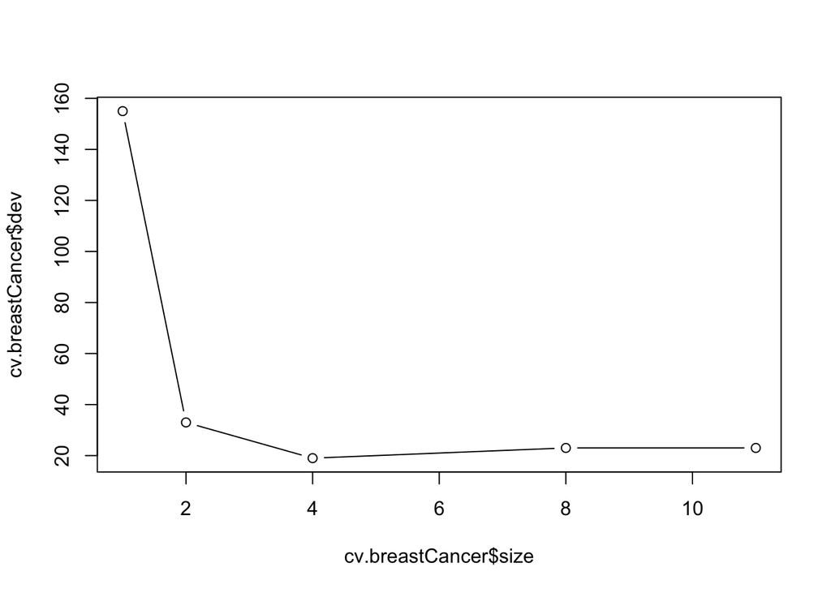

```r
  #make suitable plots to see the optimal value of the tuning parameter α
    par(frow=c(1,2))
    plot(cv.breastCancer$size,cv.breastCancer$dev,type="b")
```

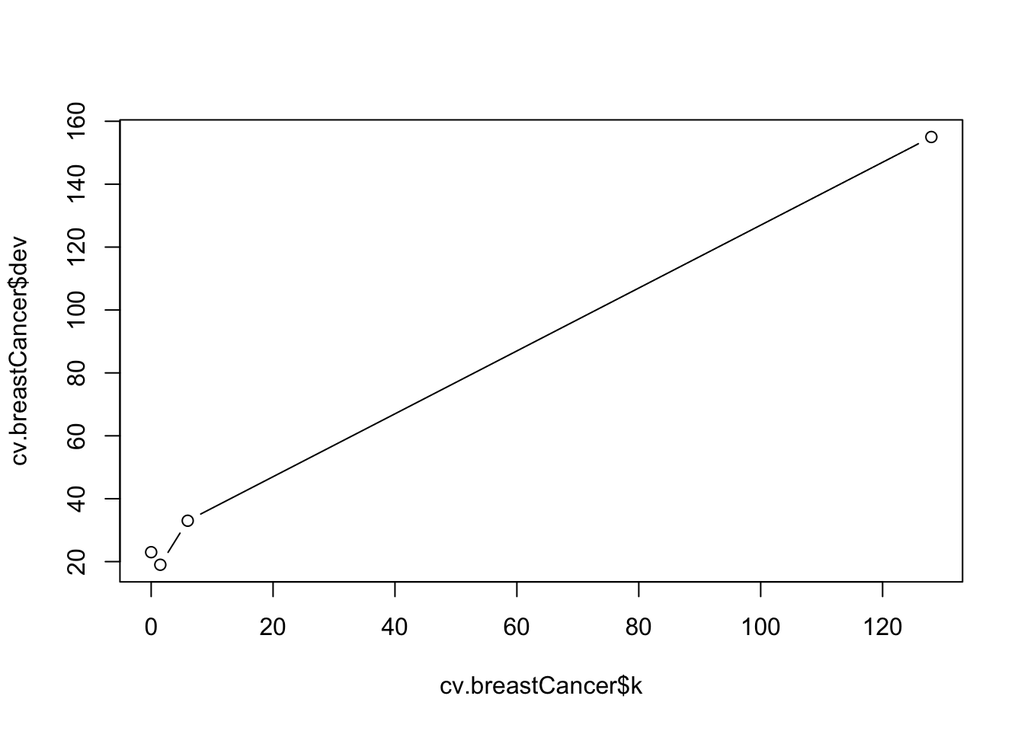

```r
    plot(cv.breastCancer$k,cv.breastCancer$dev,type="b")
```

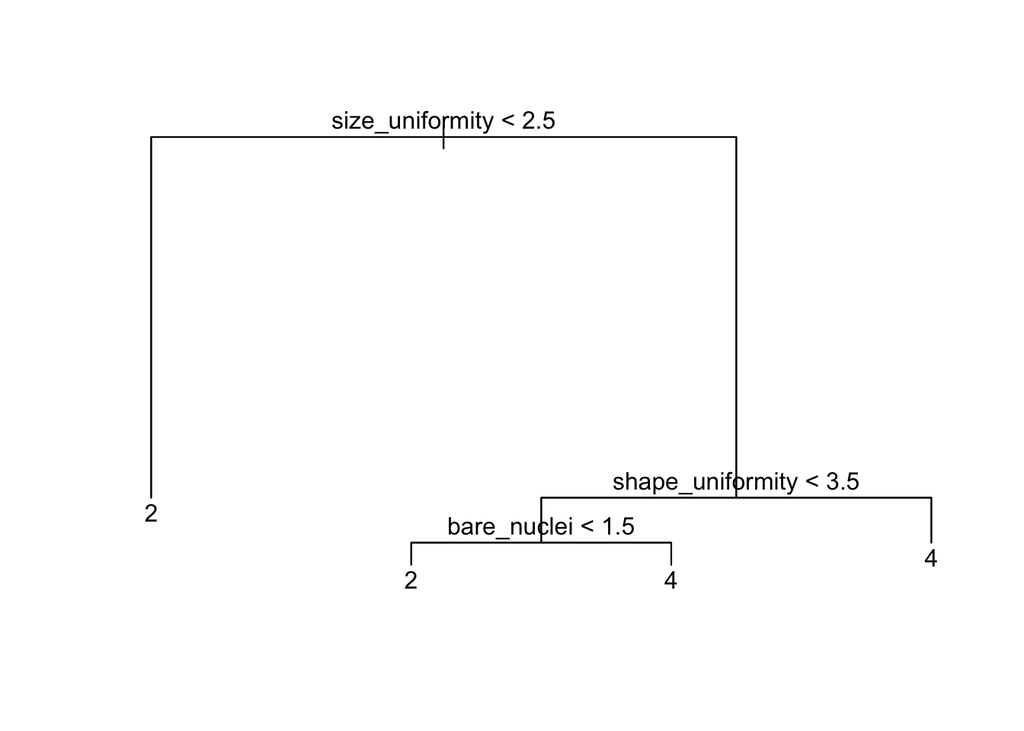

```r
    #size=4 is the best since it has the least deviation value.

    #show the results
    prune.breastCancer <- prune.misclass(tree.breastCancer,best=4)
    plot(prune.breastCancer)
    text(prune.breastCancer)
```

#### Section 3.2 Performace Review of the Pruned Trees Model

In this section we will use the misclassification rate again as as benchmark for the accuracy of the model. In this case, the model got 15/299 predictions wrong, which accounts for 5%

**Pruned Trees Misclassification Rate**

> 5 %

### Section 4. Decision Trees III: Bagged Trees and Random Forest

As previously mentioned, bagged trees and random forest are very poweful techniques, and in this section we will build and test models that implement them to obtain as a result the lowest rates in tree-based classification models so far.

#### Section 4.1: Creation of the Model

```r
  breastCancer$Class <- as.factor(breastCancer$Class)

  #bagged approach application.
  set.seed(2)
  train <- sample(1:nrow(breastCancer),400)
  breastCancer_test <- breastCancer[-train,]

  bag.breastCancer <- randomForest(Class~.-Class_binary,data=breastCancer,subset = train,mtry=9,importance=TRUE)
  bag.breastCancer
```

```
##
## Call:
##  randomForest(formula = Class ~ . - Class_binary, data = breastCancer,      mtry = 9, importance = TRUE, subset = train)
##                Type of random forest: classification
##                      Number of trees: 500
## No. of variables tried at each split: 9
##
##         OOB estimate of  error rate: 3%
## Confusion matrix:
##     2   4 class.error
## 2 240   5  0.02040816
## 4   7 148  0.04516129
```

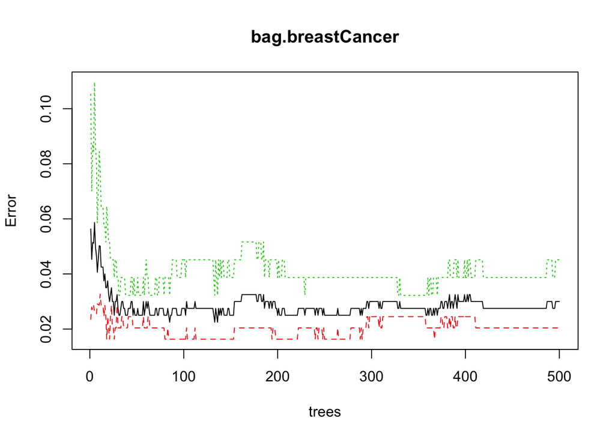

```r
  plot(bag.breastCancer)
```

```r
  yhat.bag <- predict(bag.breastCancer,newdata = breastCancer_test)
  table(prediction=yhat.bag,true=breastCancer_test$Class)
```

```
##           true
## prediction   2   4
##          2 203   3
##          4  10  83
```

```r
  #The correct rate is (203+82)/299=0.953

  #Plotting feature importance.
  importance(bag.breastCancer)
```

```
##                          2          4 MeanDecreaseAccuracy
## thickness        21.649828 18.9181295            24.625965
## size_uniformity  11.157404 25.3226589            28.536048
## shape_uniformity  7.933821 16.2599926            18.596484
## adhesion          2.345312 13.6660312            13.727780
## size_epithelial   6.821771  4.3031379             7.848687
## bare_nuclei      18.723838 19.3562625            24.685300
## bland_chromatin   5.828544 18.2715881            17.923191
## normal_nucleoli   9.544268  9.8134924            12.771331
## mitoses           2.055402 -0.6126049             1.689414
##                  MeanDecreaseGini
## thickness               8.8203890
## size_uniformity        91.7637848
## shape_uniformity       60.3375122
## adhesion                1.8996482
## size_epithelial         4.0917673
## bare_nuclei            14.1776692
## bland_chromatin         4.6507814
## normal_nucleoli         3.3742962
## mitoses                 0.3018717
```

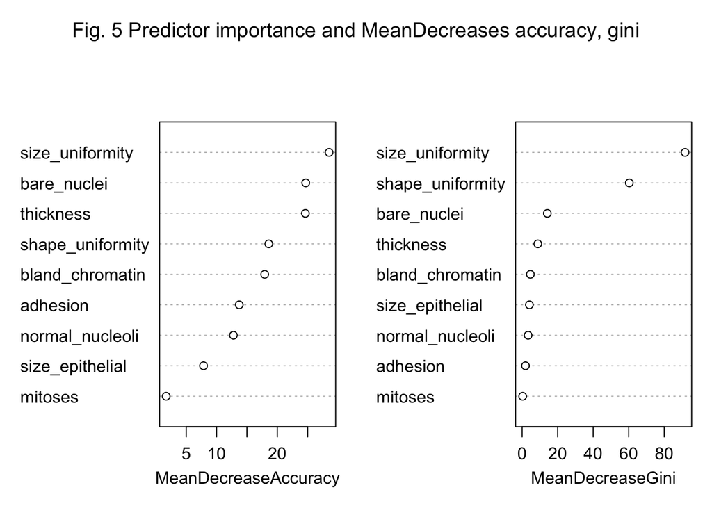

```r
  varImpPlot(bag.breastCancer, main = list("Fig. 5 Predictor importance and MeanDecreases accuracy, gini"))
```

```r
  #random forest approach application.
  bag.breastCancer_1<-randomForest(Class~.-Class_binary,data=breastCancer,subset = train,mtry=3,importance=TRUE)
  bag.breastCancer_1
```

```
##
## Call:
##  randomForest(formula = Class ~ . - Class_binary, data = breastCancer,      mtry = 3, importance = TRUE, subset = train)
##                Type of random forest: classification
##                      Number of trees: 500
## No. of variables tried at each split: 3
##
##         OOB estimate of  error rate: 2.25%
## Confusion matrix:
##     2   4 class.error
## 2 240   5  0.02040816
## 4   4 151  0.02580645
```

```r
  yhat.bag_1<-predict(bag.breastCancer_1,newdata = breastCancer_test, type="class")
  table(prediction=yhat.bag_1,true=breastCancer_test$Class)
```

```
##           true
## prediction   2   4
##          2 203   2
##          4  10  84
```

```r
  #The correct rate is (203+83)/299=0.957
```

As we can see in the first figure, as the number of trees in the model increases, the error rate tends to decrease, all up to a certain point where additional trees do not account for significant decreases in the error rate, and *size_uniformity* and *shape_uniformity* keep being the best predictors for assesing whether the tumor will turn out to be benign or not.

#### Section 4.2: Performance Review of the Bagged Trees and Random Forest Models

In this section the performance of the Bagged Trees and the Random Forest classification modeld will be assesed by means of computing the misclassification rate, which we will assume to be equal to the outputted OOB (Out-of-bag error), which is the mean prediction error on each training sample xᵢ, using only the trees that did not have xᵢ in their bootstrap sample.

**Bagged Trees Misclassification Rate**

> 3 %

### Section 5. Alternatives to tree-based methods in classification problems I: Logistic Regression

In this section, we will build a logistic regression model and perform cross-validation on it using Akaike’s Information Criterion, which a way of penalizing a model for having too many variables. Thus, the lower the AIC value, the better.

It is possible to obtain the AIC by means of this equation, where n represents the number of cases in the model, SSE the sum of squared errors for the model and k the number of predictor variables.

$$AIC=n(ln)\frac{SSE}{n}+2k$$

#### Section 5.1: Creation of the Logistic Regression Model

```r
set.seed(100)

breastCancer.raw<-read.csv("breast-cancer-wisconsin.data.csv")

#rename the variables.
breastCancer<-dplyr::rename(breastCancer.raw, ID=id.number,
          thickness=Clump.Thickness,
          size_uniformity=Uniformity.of.Cell.Size,
          shape_uniformity=Uniformity.of.Cell.Shape,
          adhesion=Marginal.Adhesion,
          size_epithelial=Single.Epithelial.Cell.Size,
          bare_nuclei=Bare.Nuclei,
          bland_chromatin=Bland.Chromatin,
          normal_nucleoli=Normal.Nucleoli,
          mitoses=Mitoses)

rownames(breastCancer)<-c(1:nrow(breastCancer))

#Legend labelling
breastCancer$Class <- ifelse(breastCancer$Class == "2",0,
                          ifelse(breastCancer$Class == "4", 1, NA))

#Splitting dataset into approximately 50:50
train<-sample(1:nrow(breastCancer),400)

#Creating and storing test and training datasets
data.training<-breastCancer[train,]
data.test<-breastCancer[-train,]


#cross-validation on logistic model using AIC.
loocv_default<-function(dataset){
  n<-nrow(dataset)
  loocv_prediction<-rep(0,n)

  for (i in 1:n){
    dataset.loocv<-dataset[-i,]
    glm.model<-glm(Class~bare_nuclei + thickness + bland_chromatin + shape_uniformity + adhesion + mitoses,data=data.training,binomial)
    predict_for_row<-predict(glm.model,newdata=dataset[i,],type="response")

    if (predict_for_row<0.5){loocv_prediction[i]<-0}else{loocv_prediction[i]<-1}
  }
  misclassified<-length(which(loocv_prediction!=dataset$Class))
  rate<-misclassified/n
  return(rate)
}

loocv_default(data.training)
```

```
## [1] 0.0175
```

#### Section 5.2: Performace Review of the Logistic Regression Model

In this section the performance of the Logistic Regression classification model will be assesed using the misclassification rate, which is the number that the previous call to the function just gave as an output.

**Logistic Regression Misclassification Rate:**

> 1.75 %

### Section 6. Alternatives to tree-based methods in classification problems II: K Nearest Neighbours

K Nearest Neighbours is another supervised learning technique that allows us to classify the data into factors based on a given training dataset, returning a solution based on the association of new cases with the K most similar cases in the training data.

#### Section 6.1: Creation of the KNN Model

```r
#run knn on training data
set.seed(100)

breastCancer.raw<-read.csv("breast-cancer-wisconsin.data.csv")

#rename the variables.
breastCancer<-dplyr::rename(breastCancer.raw, ID=id.number,
          thickness=Clump.Thickness,
          size_uniformity=Uniformity.of.Cell.Size,
          shape_uniformity=Uniformity.of.Cell.Shape,
          adhesion=Marginal.Adhesion,
          size_epithelial=Single.Epithelial.Cell.Size,
          bare_nuclei=Bare.Nuclei,
          bland_chromatin=Bland.Chromatin,
          normal_nucleoli=Normal.Nucleoli,
          mitoses=Mitoses)

rownames(breastCancer)<-c(1:nrow(breastCancer))

#Splitting dataset into approximately 50:50
train<-sample(1:nrow(breastCancer),400)
#Creating and storing test and training datasets

data.training<-breastCancer[train,]
data.test<-breastCancer[-train,]

data.training.pred<-knn(data.training[,-c(1,7,11:13)], data.training[,-c(1,7,11:13)], cl=data.training[,11], k=10)
table(pred=data.training.pred,actual=data.training[,11])
```

```
##     actual
## pred   2   4
##    2 250   6
##    4   7 137
```

```r
#perform knn on test data
set.seed(100)

breastCancer.raw<-read.csv("breast-cancer-wisconsin.data.csv")

#rename the variables.
breastCancer<-dplyr::rename(breastCancer.raw, ID=id.number,
          thickness=Clump.Thickness,
          size_uniformity=Uniformity.of.Cell.Size,
          shape_uniformity=Uniformity.of.Cell.Shape,
          adhesion=Marginal.Adhesion,
          size_epithelial=Single.Epithelial.Cell.Size,
          bare_nuclei=Bare.Nuclei,
          bland_chromatin=Bland.Chromatin,
          normal_nucleoli=Normal.Nucleoli,
          mitoses=Mitoses)

rownames(breastCancer)<-c(1:nrow(breastCancer))

#Splitting dataset into approximately 50:50
train<-sample(1:nrow(breastCancer),400)
#Creating and storing test and training datasets

data.training<-breastCancer[train,]
data.test<-breastCancer[-train,]

#KNN
library("class")
data.test.pred<-knn(data.training[,-c(1,7,11:13)], data.test[,-c(1,7,11:13)], cl=data.training[,11], k=10)
table(pred=data.test.pred,actual=data.test[,11])
```

```
##     actual
## pred   2   4
##    2 194   9
##    4   7  89
```

#### Section 6.2: Performance Review of the KNN

In this section the performance of the KNN classification model will be assesed by means of computing the misclassification rate. When it comes to the trainig data, the model got 13/400 predictions wrong, which amounts to 3.25%.

In the test data, it got 16/299 predictions wrong, which amounts to 5.3%. Obviusly, we expected the model to be less accurate with the test data, which explains the presence of a higher misclassification rate.

**KNN Misclassification Rate:**

> 5.3 %

## Conclusion and Final Thoughts

This report presents an analysis of the Wisconsin Breast Cancer Dataset and an example of how to build both tree-based and non-tree-based statistical learning classification models to predict the diagnosis of breast cancer tumour class (benign or malignant) through the analysis of cytological characteristics of breast cancer cells.

However, when it comes to the two non-tree based approaches built in the latter sections of this report, k-nearest-neighbors and logistic regression, we must acknowledge logistic regression as the best method overvall because it presents a misclassification rate of 1.75%.

As this analysis shows, machine learning has the potential to become a key tool in the advance of modern computational biology, as it holds the capacity to, given enough quality data, make accurate predictions that may help improve medical treatment and, hopefully, advance some diagnoses.

### References

- James et al. (2013) An Introduction to Statistical Learning: With applications in R. Springer.
- Zumel, N. and Mount, J. (2014). Practical Data Science with R. Manning Publications.
- Lantz, B. (2013). Machine Learning with R. Packt Publishing.
- Conway, D. and White, J. (2012) Machine Learning for Hackers.
- Material used in the *Introduction to Machine Learning* class at DataCamp